# lesson5 practice 探索多个变量

## P1:带有分面和颜色的价格直方图

Create a histogram of diamond prices. Facet the histogram by diamond color and use cut to color the histogram bars.

The plot should look something like this. http://i.imgur.com/b5xyrOu.jpg

Note: In the link, a color palette of type ‘qual’ was used to color the histogram using scale_fill_brewer(type = ‘qual’)

创建钻石价格的直方图。 用钻石颜色来描绘直方图，并使用切割为直方图条纹着色。 图形看起来应该像这样http://i.imgur.com/b5xyrOu.jpg 注意：在链接中，使用“qual”类型的调色板使用scale_fi11_brewer（type =‘qual’）为直方图着色。

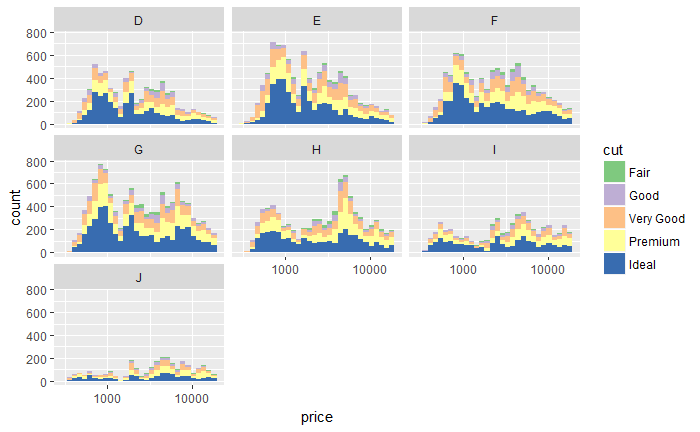

## P2:价格与按切工填色的表格

注意各种细节配置。

Create a scatterplot of diamond price vs. table and color the points by the cut of the diamond.

The plot should look something like this. http://i.imgur.com/rQF9jQr.jpg

Note: In the link, a color palette of type ‘qual’ was used to color the scatterplot using scale_color_brewer(type = ‘qual’)

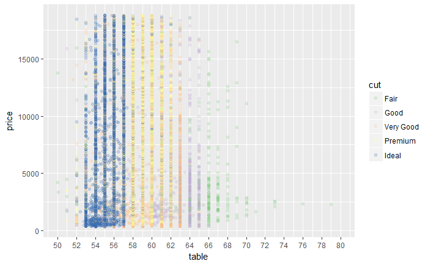

## P3:典型表值

大多数完美idea切工钻石的典型表范围是多少？

大多数优质premium切工钻石的典型表范围是多少？

使用你在之前练习中创建的图表查看答案。无需进行汇总。

## P4:价格与体积和钻石净度

Create a scatterplot of diamond price vs. volume (x * y * z) and color the points by the clarity of diamonds. Use scale on the y-axis to take the log10 of price. You should also omit the top 1% of diamond volumes from the plot.

Note: Volume is a very rough approximation of a diamond’s actual volume.

The plot should look something like this. http://i.imgur.com/excUpea.jpg

Note: In the link, a color palette of type ‘div’ was used to color the scatterplot using scale_color_brewer(type = ‘div’)

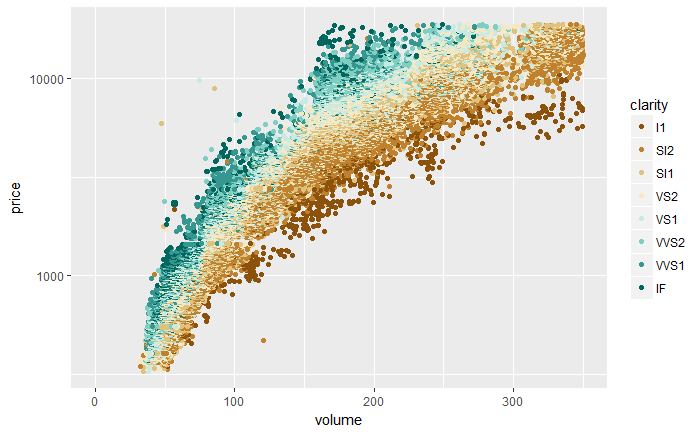

## P5:新建友谊的比例

一个有趣的问题，用新交友数来反映人的性格。

Many interesting variables are derived from two or more others. For example, we might wonder how much of a person’s network on a service like Facebook the user actively initiated. Two users with the same degree (or number of friends) might be very different if one initiated most of those connections on the service, while the other initiated very few. So it could be useful to consider this proportion of existing friendships that the user initiated. This might be a good predictor of how active a user is compared with their peers, or other traits, such as personality (i.e., is this person an extrovert?).

Your task is to create a new variable called ‘prop_initiated’ in the Pseudo-Facebook data set. The variable should contain the proportion of friendships that the user initiated.

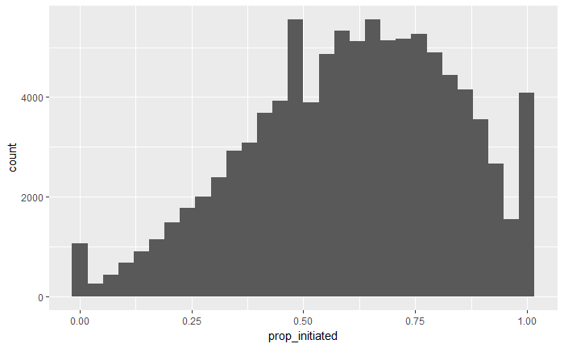

## P6: prop_initiated 与使用时长

Create a line graph of the median proportion of friendships initiated (‘prop_initiated’) vs. tenure and color the line segment by year_joined.bucket.

Recall, we created year_joined.bucket in Lesson 5 by first creating year_joined from the variable tenure. Then, we used the cut function on year_joined to create four bins or cohorts of users.

(2004, 2009] (2009, 2011] (2011, 2012] (2012, 2014]

The plot should look something like this. http://i.imgur.com/vNjPtDh.jpg OR this http://i.imgur.com/IBN1ufQ.jpg

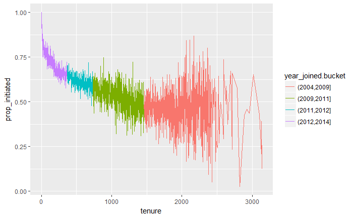

## P7: 平滑化 prop_initiated 与使用时长

Smooth the last plot you created of of prop_initiated vs tenure colored by year_joined.bucket. You can bin together ranges of tenure or add a smoother to the plot.

There won’t be a solution image for this exercise. You will answer some questions about your plot in the next two exercises.

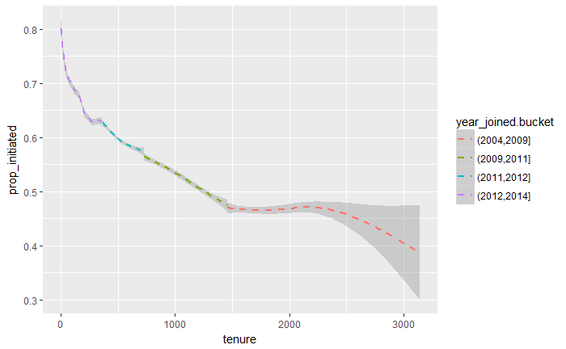

## P8: 最大的 prop_initiated 组

平均来说，哪个组发起的 Facebook 好友请求比例最大？你在上个练习中创建的带平滑器的图可以帮你回答这个问题。

平均来说，哪个组发起的 Facebook 好友请求比例最大？你在上个练习中创建的带平滑器的图可以帮你回答这个问题。

## P9: 最大的组均值 prop_initiated

对于发起好友请求比例最大的组，这个组的平均（即均值）好友请求比例是多少？

```r
summary(subset(pf, pf$year_joined.bucket == '(2012,2014]')$prop_initiated)
```

```
   Min. 1st Qu.  Median    Mean 3rd Qu.    Max.    NA's
 0.0000  0.5115  0.7018  0.6654  0.8490  1.0000    1468
```

你认为该组发起的好友请求比例大于其他组的原因是什么？ 新加入的好友数比较少

## P10: 经过分组、分面和填色的价格/克拉

Create a scatter plot of the price/carat ratio of diamonds. The variable x should be assigned to cut. The points should be colored by diamond color, and the plot should be faceted by clarity.

The plot should look something like this. http://i.imgur.com/YzbWkHT.jpg.

Note: In the link, a color palette of type ‘div’ was used to color the histogram using scale_color_brewer(type = ‘div’)

注意，添加抖动增加噪音

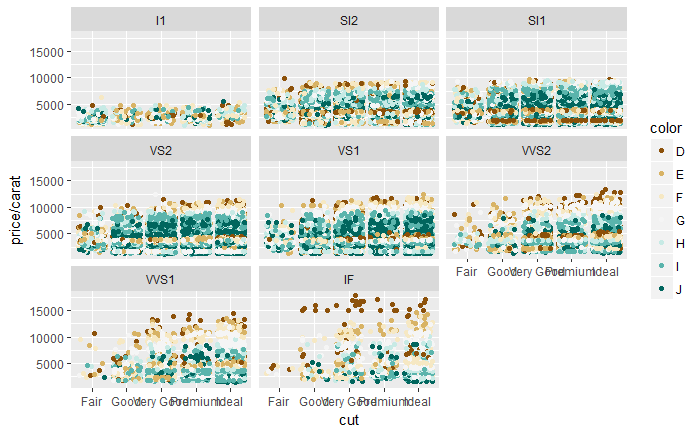

## P11: Gapminder 多变量分析

(略)